# Simulated Redistricting Maps as a Baseline

Five Thousand Maps Nobody Drew

Democracy’s Data

Last updated September 13, 2026 at 10:53a EDT

A gerrymandered congressional district can look perfectly tidy, and an innocent one can look like a spilled drink. Rivers wander, county lines wander, and some of the strangest districts in America were drawn strangely in order to keep one community inside one seat. The eye is a poor instrument here. So how do you tell a gerrymander from a map that merely looks odd?

You need something to hold the map against. Not an ideal map, which nobody can define, but the ordinary range: the maps a process with no interest in the outcome would have produced. Nobody drew those maps, because nobody had any reason to. This brief uses five thousand of them per state, drawn by a computer, and asks where each state’s real map falls among them. That position is the evidence. A map inside the range is unremarkable however it looks, and a map far outside it has something to explain.

## The test

Using the ALARM Project’s **50-State Redistricting Simulations**, a collection built by a research group at Harvard led by Kosuke Imai, described at https://alarm-redist.org/fifty-states/ and published on the Harvard Dataverse at https://doi.org/10.7910/DVN/SLCD3E. For every state with more than one congressional district it supplies two things side by side. One is the **enacted plan**, the map the state actually put in force after the 2020 census. The other is 5,000 alternatives drawn by a program that never saw a voter’s party or a resident’s race.[^1] That program had three rules: equal population between districts, districts in one connected piece, and districts that are not needlessly sprawling. Call the second set the **neutral maps**, and the 5,000 of them taken together the **ensemble**.

That pairing is why this source rather than another. Being unusual is a statement about a distribution, not about a map, and no single plan carries a distribution. This is the collection that ships one beside the enacted plan for every state at once.

**Two files meet here, and each count below is a join.** The enacted plan and the ensemble are separate objects that agree on nothing but the state’s postal code and the district numbers inside it. Match them on that, and you can subtract. Join Keys and Crosswalks works the mechanics of exactly that kind of match, and the repair for a key that misbehaves: a crosswalk, a table that translates one set of areas into another. The assumption this join quietly adds is that the two files describe the same electorate under the same rules, differing only in where the lines went.

## The data

Almost nothing you will read below arrives in the download. Every count is computed from it, and the definitions are where the argument lives.

A district counts as **Black-plurality** if Black voting-age population is the largest of every racial and ethnic group reported for it. That is stricter than “more Black residents than white,” which can be true in a district where Hispanic residents outnumber both. An earlier version of this brief used the looser test and misclassified several genuinely Hispanic-plurality districts. The error was caught by comparing the national count against an independent tally, which is worth doing to any number of this kind.

`black_by_state.csv` gives each state `actual_black`, `neutral_black_mean` and `gerry_black`, plus `n_plans_tied_at_max`. That last column matters. Thousands of the 5,000 plans are usually tied for a state’s highest possible Republican seat count, and `gerry_black` takes whichever of those tied plans holds the fewest Black-plurality districts. Read Texas’s row to see the three numbers made. Its enacted map holds 2 Black-plurality districts. Count the same way in each of the 5,000 neutral maps and the average is 0.21, which means most of them hold none. 8 of the 5,000 tie for the highest Republican seat count any of them reaches, and `gerry_black` is whichever of those 8 holds the fewest Black-plurality districts: 0. It is not a real gerrymander anybody drew. It is the most adversarial map available inside an ensemble that was never told to be adversarial about race.

Two cleaning decisions travel with the numbers. Six states have one House seat and so nothing to simulate, leaving 44 states and 429 districts everywhere below. And Alabama’s and Louisiana’s enacted counts carry a hand correction, because courts ordered new maps after the dataset’s own snapshot.[^2]

> **Before you scroll, make two predictions.** If district lines were drawn by a process blind to party, would there be more competitive seats than there are today, or about the same? And would that hold in every state, or only in most of them?

## What it says about democracy

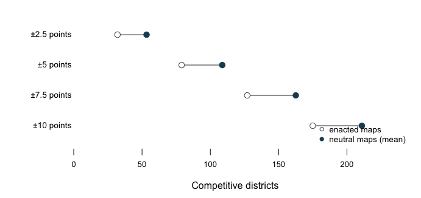

**Figure 1. Neutral maps produce more competitive districts, at every threshold checked.** A dumbbell, because the question is a distance: two counts of the same thing, and the gap between them is the whole finding. Across 44 states and 429 districts, the enacted maps hold 79 districts within five points of even against a neutral average of 108.8, about 1.38 times as many.

That consistency is the point. One threshold could be an accident of where the line falls. Four thresholds moving the same direction by comparable margins is a fact about the country’s districts, not a choice about a cutoff.

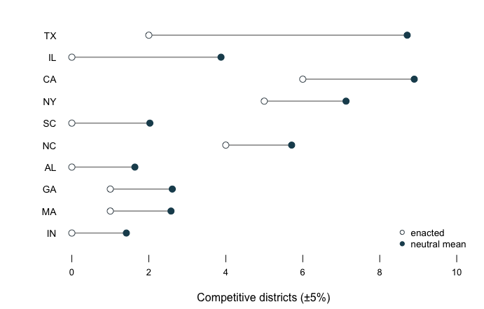

**Figure 2. Texas carries the largest gap of any state.** Its enacted map holds 2 districts within five points of even out of 38, where the neutral maps average 8.7 — more than four times as many. No other state comes close.

The exceptions are the interesting part. Illinois and California sit next on that list, so the pattern is not one-sided, though states with Republican-controlled legislatures dominate the largest gaps. Illinois was drawn by its legislature. California was drawn by an independent commission, and its map is third in the country for distance from its own neutral ensemble. In 9 states a commission’s map becomes law without a legislative vote, and most of those states sit close to their ensembles. California says a commission is not a machine for producing the neutral map.

The lines decide something besides competition. Section 2 of the Voting Rights Act forbids lines that dilute a racial minority’s ability to elect the candidates it prefers.[^3] The neutral maps allow a sharper question than whether a given state diluted anyone. They allow you to ask what happens to Black representation when a legislature stops trying to preserve it and tries instead to win every seat the lines can yield.

The next figure is restricted to the 20 states Republicans controlled after the 2020 census. A Republican gerrymander is only a live possibility where Republicans hold the pen, and running the same test on a Democratic-controlled state would ask about a map nobody there has a reason to draw.

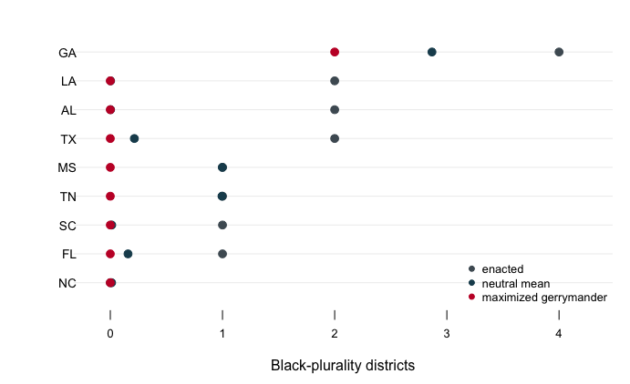

**Figure 3. Georgia is the only state that keeps a Black-plurality seat under a maximized gerrymander.** Across those states the enacted maps hold 14 Black-plurality districts and the neutral maps average 5.3. The most adversarial map inside the simulations holds 2, a cut of about 86%. Every state with exactly one such district today loses it: FL, MS, SC, TN.

Two different stories sit inside that one chart. In Alabama and Louisiana the neutral maps rarely produce a Black-plurality district on their own, so those seats exist because a judge required them. In Georgia the Black population is numerous and concentrated enough that neutral maps produce such districts most of the time, and a maximized gerrymander still cuts 4 down to 2. Concentration protects a group from accidental erasure. It does not protect them from a map drawn on purpose.

Kenny and colleagues (2026) run the harder version of this, with a real seat-maximizing search across all fifty states, and reach the same shape of answer.[^4]

## What this brief cannot tell you

**The neutral maps followed three rules, and a real map has to follow more.** Federal law adds two hard ones: near-exact equal population between congressional districts,[^5] which the simulations honoured, and the Voting Rights Act’s limits on how lines may treat racial minorities, which they never considered. Everything else is state law and differs by state. Many states require respect for county and city boundaries, or for communities of interest, or for the cores of prior districts. That last rule protects incumbents by protecting the shape they were elected in.

Those criteria conflict, and few states rank them. A state can point at a neutral map and say it split a county the state’s own constitution protects, and the state would be right. It does not follow that the gaps in Figures 1 and 2 are explained by county lines, and nothing here measures how much of each gap the extra rules could account for.

**That objection now has legal force.** In *Louisiana v. Callais* (2026) the Supreme Court held that a map offered to show what could have been drawn must meet all of the state’s legitimate objectives, its stated political goals included.[^6] Nothing in a 5,000-map ensemble built on three rules can clear that.

Two smaller limits. Party control of a legislature is a rough proxy for who drew a map, and for at least three of the 20 states in Figure 3 it is the wrong answer. Iowa’s maps are drafted by nonpartisan staff, Utah had an advisory commission, and Ohio’s process is a hybrid. Every count here is also a snapshot of maps and law that both keep moving.

## What you should have learned

- A map’s shape is not evidence, and its position in a distribution of maps is. That is the whole move: build the plans nobody had a reason to draw, then locate the real one among them.
- Neutral maps produce about 1.38 times as many competitive districts as the enacted maps do, 108.8 against 79 within five points of even, and the result survives every threshold checked.
- The national gap is concentrated, not spread: Texas alone runs 2 competitive districts against a neutral average of 8.7.
- A commission is not a machine for producing the neutral map. Commission states mostly sit close to their ensembles, and California, drawn by a commission, sits third in the country for distance from its own.
- Under the most adversarial map the simulations contain, Black-plurality districts in the 20 states fall from 14 to 2, and only Georgia keeps any.

## Extensions

None of these is answered above, and every one can be answered from the tables the Sources section hands over.

- `competitive_by_state.csv` puts `enacted` against `neutral_mean` for every state. Sort by the difference. Which maps sit furthest from what a neutral process produces, and in which direction?
- `competitive_national.csv` repeats the comparison at four values of `threshold`. Does the conclusion survive changing what counts as competitive?
- `black_by_state.csv` compares `actual_black` against `neutral_black_mean`. Find the states whose enacted map produces more than neutrality would, and the states where it produces fewer.
- `who_draws_states.csv` gives each state its `congressional_authority`. Match it to the gap in `competitive_by_state.csv`. Do commission states really look different?
- **Stretch.** `black_by_state.csv` also has `n_plans_tied_at_max`. Where that number is in the thousands, the state’s highest Republican seat count is easy to reach. Ask what that implies about how much skill a gerrymander takes.
- **Stretch.** The ALARM collection is rebuilt as states redraw. Download a state that has enacted a new map since this snapshot and see whether its position in the ensemble moved.

## Sources

**Data**

- ALARM Project, **50-State Redistricting Simulations**, Harvard Dataverse, doi:10.7910/DVN/SLCD3E. Enacted plans and 5,000 neutral simulated plans per state, for every state with more than one congressional district. https://doi.org/10.7910/DVN/SLCD3E (the Dataverse answers a download request with a “202 accepted” before serving the file). The project’s own description of the collection: https://alarm-redist.org/fifty-states/
- National Conference of State Legislatures, *Redistricting Law 2020* (Denver: NCSL, October 2019), Exhibit 5.1 and the Iowa note on p. 91, keyed in for who draws each congressional map; chapter 4 for the redistricting criteria a real map has to satisfy. https://www.ncsl.org/redistricting-and-census/redistricting-law-2020

**The data itself**

Every figure above is drawn from these tables. They are plain CSV, they open in a spreadsheet, and they are yours to take further.

`black_by_state.csv`, `black_national.csv`, `competitive_by_state.csv`, `competitive_national.csv`, `who_draws.csv`, `who_draws_states.csv`

One more file is not data about the subject – it is how this chapter checked its own numbers: `facts.csv`, the individual numbers the text above quotes.

**Cases**

- *Louisiana v. Callais*, 608 U.S. ___ (2026), on what an illustrative map must now achieve to count as evidence. https://www.supremecourt.gov/opinions/25pdf/24-109_21o3.pdf
- *Allen v. Milligan*, 599 U.S. 1 (2023), the ruling behind Alabama’s and Louisiana’s court-ordered maps. https://www.law.cornell.edu/supremecourt/text/21-1086
- *Karcher v. Daggett*, 462 U.S. 725 (1983), on how equal congressional districts must be. https://www.law.cornell.edu/supremecourt/text/462/725
- Section 2 of the Voting Rights Act, 52 U.S.C. § 10301. https://www.law.cornell.edu/uscode/text/52/10301

**Academic literature**

- McCartan, C. and Imai, K. (2023). “Sequential Monte Carlo for Sampling Balanced and Compact Redistricting Plans.” *The Annals of Applied Statistics* 17(4): 3300–3323. The algorithm behind the 5,000 maps. https://doi.org/10.1214/23-AOAS1763
- Kenny, C. T., Zhou, B., Simko, T., and Imai, K. (2026). “Weakening the Voting Rights Act Reduces Minority Representation and Electoral Competition.” Working paper. A more thoroughly optimized version of this brief’s second question, run across all 50 states with a genuine seat-maximizing search rather than a best-of-5,000 selection. Its published estimate is a national decline of roughly half in minority-opportunity districts. https://imai.fas.harvard.edu/research/callais/

Rebuild this data yourself, with an AI assistant

```
I want to rebuild a public dataset from its original source, without
any starting files. Please do the following and show your work.

THE SOURCE. The ALARM Project's 50-State Redistricting Simulations,
on the Harvard Dataverse: doi:10.7910/DVN/SLCD3E. For every state
with more than one congressional district, it holds a table with one
row per district per redistricting plan. Query the Dataverse API for
the file list, then download each state's "<STATE>_cd_2020_stats.tab"
file with ?format=original appended to the access URL, which returns
the original CSV rather than Dataverse's re-encoded copy. Forty-four
states qualify; the six single-district states (Alaska, Delaware,
North Dakota, South Dakota, Vermont, Wyoming) are not in the file at
all, because a state with one district has nothing to simulate.

Each file is 7 to 18 MB, so do not commit the raw downloads -- pull
them into a temporary folder, compute what you need, and keep only
the small summary tables.

The `draw` column tells you which plan each row belongs to:
"cd_2020" is the map the state actually enacted after the 2020
census; the 5,000 draws numbered 1 through 5000 are computer-drawn
plans, built to the same population-equality, contiguity, and
compactness rules, with no information about party or race.

WHAT TO BUILD.
1. COMPETITIVENESS. For each state and each of four thresholds
   (2.5, 5, 7.5, 10 percentage points), count the districts within
   that many points of a 50-50 two-party vote share (columns ndv and
   nrv) in the enacted plan, and average the same count across the
   5,000 neutral plans.
2. BLACK REPRESENTATION UNDER A MAXIMIZED GERRYMANDER. Restricted to
   the 20 states Republicans controlled after the 2020 census (TX,
   FL, GA, NC, SC, TN, AL, MS, LA, AR, MO, KS, OK, IA, NE, IN, OH,
   KY, WV, UT). A district is "Black-plurality" if Black voting-age
   population is the largest of all eight reported VAP columns
   (vap_white, vap_black, vap_hisp, vap_aian, vap_asian, vap_nhpi,
   vap_other, vap_two) -- not merely larger than white VAP alone.
   For each state, report the enacted count, the mean across the
   5,000 neutral plans, and -- among whichever plans are tied for
   that state's highest Republican-seat count -- the fewest
   Black-plurality districts found among them.

A note on staleness: the enacted ("cd_2020") plan in this dataset
predates two court-ordered maps that added a second Black-opportunity
district for the 2024 election onward, in Alabama (Allen v. Milligan,
2023) and Louisiana (Robinson v. Ardoin, 2024 -- the same map
Louisiana v. Callais later ruled on in 2026). If you want the current
picture rather than the file's own snapshot, add one seat to each of
those two states' enacted counts by hand, and say that you did.

CHECK YOUR WORK. The copy this book used was downloaded in August 2026.
If your rebuild matches it, across the 44 states (429 districts) you
should find:
- 79 districts competitive within 5 points in the enacted maps,
  against a mean of 108.8 across the neutral plans
- Texas: 2 competitive districts enacted, 8.7 expected under neutral
  maps -- the largest gap of any state
Restricted to the 20 Republican-controlled states (191 districts),
with the Alabama/Louisiana correction applied:
- 14 Black-plurality districts enacted, a mean of 5.3 under neutral
  maps, and 2 under a maximized gerrymander
- Georgia is the only one of the 20 that keeps any Black-plurality
  district under the maximized gerrymander (4 enacted, 2 remaining)
```

[^1]: The program is described in Cory McCartan and Kosuke Imai, “Sequential Monte Carlo for Sampling Balanced and Compact Redistricting Plans,” *Annals of Applied Statistics* 17, no. 4 (2023): 3300–3323, https://doi.org/10.1214/23-AOAS1763.
[^2]: Alabama’s second majority-Black district followed *Allen v. Milligan*, 599 U.S. 1 (2023), https://www.law.cornell.edu/supremecourt/text/21-1086. Louisiana’s, drawn in 2024 after the same ruling, was held an unconstitutional racial gerrymander in *Louisiana v. Callais* (2026), https://www.supremecourt.gov/opinions/25pdf/24-109_21o3.pdf, after this snapshot was taken.
[^3]: 52 U.S.C. § 10301: https://www.law.cornell.edu/uscode/text/52/10301.
[^4]: Christopher T. Kenny, Brian Zhou, Tyler Simko and Kosuke Imai, “Weakening the Voting Rights Act Reduces Minority Representation and Electoral Competition,” working paper (2026), https://imai.fas.harvard.edu/research/callais/.
[^5]: *Karcher v. Daggett*, 462 U.S. 725 (1983), https://www.law.cornell.edu/supremecourt/text/462/725.
[^6]: *Louisiana v. Callais*, No. 24-109, slip op. at 29–30 (U.S. Apr. 29, 2026), https://www.supremecourt.gov/opinions/25pdf/24-109_21o3.pdf.